# UVic Biology R Handbook

### Add a legend

Use legend() after your plot to add a legend.

You specify the text (ie the labels), and then pch for point types and col for colours if you have points, or just fill for the colours if you have boxes/bars filled with colour rather than points.

The first thing to go after the brackets will be the legend position, either coordinates (ie 4,5 for x=4, y=5) or “bottomright”, “bottom”, “bottomleft”, “left”, “topleft”, “top”, “topright”, “right” and “center”.

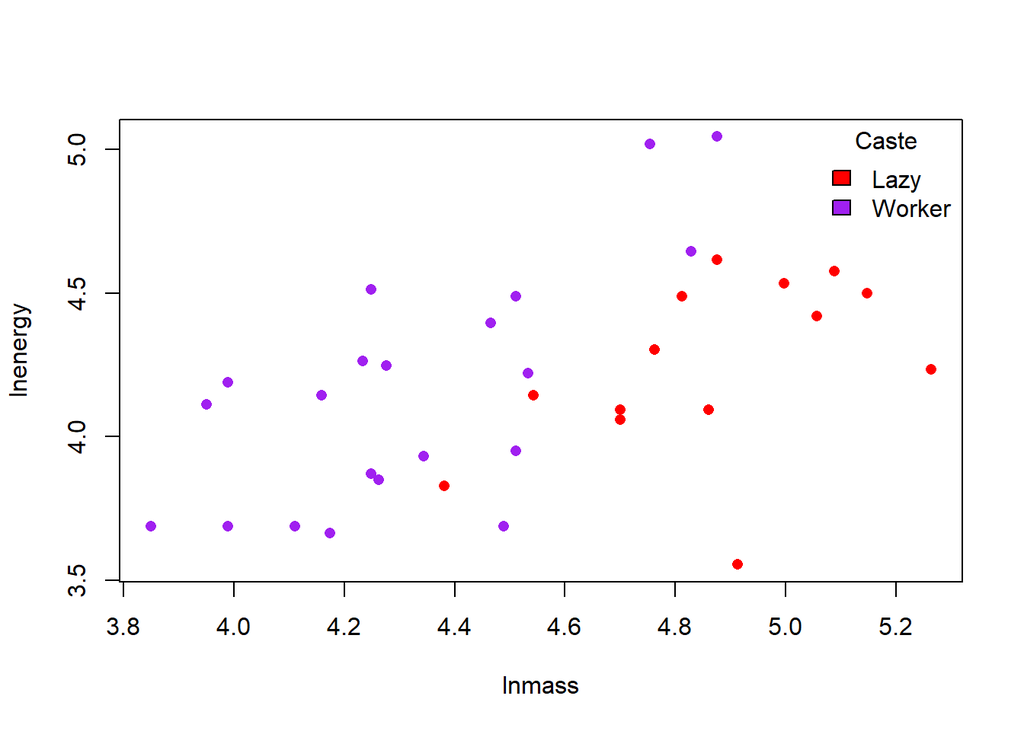

```r
colours<-c("red", "purple")#define colours you want to use
plot(lnenergy~lnmass, data=MoleRats, pch=16, col=colours[as.numeric(MoleRats$caste)]) #more customizable colour changes based on grouping variable. The first level is turned to a "1" and second level into a "2" by as.numeric, allowing me to get either the first colour or second colour of my object "colours" depending on the group (ie lazy or worker caste).
legend("topright", c("Lazy", "Worker"), fill=colours, bty="n", title="Caste") #use bty="n" to get rid of the box around the legend. Delete this argument if you want the box. I can tell from levels(MoleRats$caste) that lazy is the first level and worker the second, so lazy would become 1 and worker 2; hence lazy is the first colour.
```

```r
#Can use cex argument to change text size
```